# Hooper ESM244 HW1 Task 2

Tess Hooper

2/5/2020

## *Summary*

Principal Component Analysis (PCA) can be useful when trying to understand correlations between variables in a large dataset. PCA methodology allows us to comprehensively analyze our data and extract as much information as possible in ony two dimensions. When conducting a PCA, our principle components are chosen based on the greatest variance. This analysis explores the relationship between nutrients found in common breakfast cereals, such as Kellog’s Raisin Bran and General Mill’s Cheerios.

```r
### Explore and wrangle nutrient data

nutrients_df <- nutrients %>%
  clean_names() # Clean data so headers are in snake case

## Filter out Breakfast Cereal foodgroup to explore

cereals <- nutrients_df %>%
  filter(food_group == c("Breakfast Cereals")) %>%
  select(-contains("common_name")) %>% # Get rid of common name column
  select(-contains("scientific_name")) %>% # Get rid of scientific name column
  select(-contains("usrda")) # Get rid of USRDA nutrient columns (will stick with earlier vitamin columns)
```

#### 1. Perform Principal Component Analysis on Breafast Cereal Nutrients

```r
#### Perform PCA on breakfast cereal food group considering nutrients (energy kcal - zinc, columns 6:28)

# Take subset of nutrient data

cereal_subset <- cereals %>%
  select(energy_kcal:zinc_mg)

# 23 components total

cereal_pca <- prcomp(cereal_subset, scale = TRUE)

#cereal_pca

# summary(cereal_pca)
# 32% of data described by first PC?
```

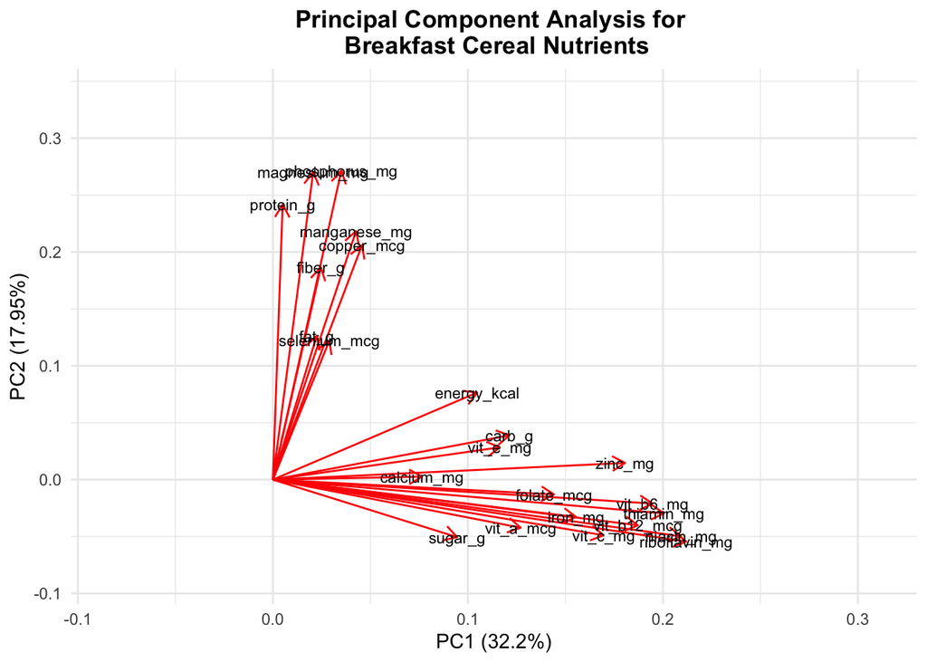

```r
## Exploratory plots

#plot(cereal_pca)
#biplot(cereal_pca)

# Clean biplot

cereal_biplot <- autoplot(cereal_pca,
                          colour = NA,
                          loadings.label = TRUE,
                          loadings.label.size = 3,
                          loadings.label.colour = "black",
                          loadings.label.repel = TRUE) +
  theme_minimal() +
  ggtitle("Principal Component Analysis for \n Breakfast Cereal Nutrients") +
  theme(plot.title = element_text(hjust=0.5, face="bold"))

cereal_biplot
```

**Figure 1. Biplot of Principal Component Analysis (PCA) for Breakfast Cereal Nutrients.** PCA plot shows correlation between certain nutrients found in common breakfast cereals, such as Kellog’s Raisin Bran and General Mill’s Cheerios.

*Interpreting our PCA*

```r
##### Interpreting biplot

### Biplots: an approximation of original multidimensional space, reduced to 2 dimensions with information about variables (as vectors) and observations (as points)

#Arrows show something about our loadings (combination of our eigenvalues, size of magnitude, and eigenvector, something about the direction

#Numbers show location of data point (e.g. 12 refers to the patient in the 12th row) → shows how the individual data points (e.g. patients) are related to one another

#Relative orientation of everything on biplot to each other is important. But if we change the orientation of everything, interpretation doesn’t change

#The length of the line/arrow indicates variance in PC direction (loading/contribution of each variable to PC)
#The angle between lines/arrows indicates correlation

#0 degree difference = correlation of 1
#180 = correlation of -1
#90 or 270 = correlation of 0

###Interpretation:
# The closer points are to each other, the smaller their Euclidean Distance - meaning they are more similar overall in multivariate space
# Biplots can make it easier to see multivariate groups and outliers
```